# Exploratory Data Analysis Report

Report by dlookr package

2019-01-05

# 1 Introduction

The EDA Report provides exploratory data analysis information on objects that inherit data.frame and data.frame.

## 1.1 Information of Dataset

The dataset that generated the EDA Report is an **‘data.frame’** object. It consists of **336,776 observations** and **19 variables**.

## 1.2 Information of Variables

The variable information of the data set that generated the EDA Report is shown in the following table.:

Information of Variables

| variables | types | missing_count | missing_percent | unique_count | unique_rate |
| --- | --- | --- | --- | --- | --- |
| year | integer | 0 | 0.0000000 | 1 | 0.0000030 |
| month | integer | 0 | 0.0000000 | 12 | 0.0000356 |
| day | integer | 0 | 0.0000000 | 31 | 0.0000920 |
| dep_time | integer | 8255 | 2.4511842 | 1319 | 0.0039165 |
| sched_dep_time | integer | 0 | 0.0000000 | 1021 | 0.0030317 |
| dep_delay | numeric | 8255 | 2.4511842 | 528 | 0.0015678 |
| arr_time | integer | 8713 | 2.5871796 | 1412 | 0.0041927 |
| sched_arr_time | integer | 0 | 0.0000000 | 1163 | 0.0034533 |
| arr_delay | numeric | 9430 | 2.8000808 | 578 | 0.0017163 |
| carrier | character | 0 | 0.0000000 | 16 | 0.0000475 |
| flight | integer | 0 | 0.0000000 | 3844 | 0.0114141 |
| tailnum | character | 2512 | 0.7458964 | 4044 | 0.0120080 |
| origin | character | 0 | 0.0000000 | 3 | 0.0000089 |
| dest | character | 0 | 0.0000000 | 105 | 0.0003118 |
| air_time | numeric | 9430 | 2.8000808 | 510 | 0.0015144 |
| distance | numeric | 0 | 0.0000000 | 214 | 0.0006354 |
| hour | numeric | 0 | 0.0000000 | 20 | 0.0000594 |
| minute | numeric | 0 | 0.0000000 | 60 | 0.0001782 |
| time_hour | POSIXct | 0 | 0.0000000 | 6936 | 0.0205953 |

The target variable of the data is **‘arr_delay’**, and the data type of the variable is **numeric**.

## 1.3 About EDA Report

EDA reports provide information and visualization results that support the EDA process. In particular, it provides a variety of information to understand the relationship between the target variable and the rest of the variables of interest.

# 2 Univariate Analysis

## 2.1 Descriptive Statistics

edaData  
19 Variables 336776 Observations

year

| n | missing | distinct | Info | Mean | Gmd |
| --- | --- | --- | --- | --- | --- |
| 336776 | 0 | 1 | 0 | 2013 | 0 |

```
 Value        2013
 Frequency  336776
 Proportion      1
```

month

| n | missing | distinct | Info | Mean | Gmd | .05 | .10 | .25 | .50 | .75 | .90 | .95 |
| --- | --- | --- | --- | --- | --- | --- | --- | --- | --- | --- | --- | --- |
| 336776 | 0 | 12 | 0.993 | 6.549 | 3.929 | 1 | 2 | 4 | 7 | 10 | 11 | 12 |

```
 Value          1     2     3     4     5     6     7     8     9    10    11    12
 Frequency  27004 24951 28834 28330 28796 28243 29425 29327 27574 28889 27268 28135
 Proportion 0.080 0.074 0.086 0.084 0.086 0.084 0.087 0.087 0.082 0.086 0.081 0.084
```

day

| n | missing | distinct | Info | Mean | Gmd | .05 | .10 | .25 | .50 | .75 | .90 | .95 |
| --- | --- | --- | --- | --- | --- | --- | --- | --- | --- | --- | --- | --- |
| 336776 | 0 | 31 | 0.999 | 15.71 | 10.12 | 2 | 4 | 8 | 16 | 23 | 28 | 29 |

lowest : 1 2 3 4 5 , highest: 27 28 29 30 31

dep_time

| n | missing | distinct | Info | Mean | Gmd | .05 | .10 | .25 | .50 | .75 | .90 | .95 |
| --- | --- | --- | --- | --- | --- | --- | --- | --- | --- | --- | --- | --- |
| 328521 | 8255 | 1318 | 1 | 1349 | 561.9 | 624 | 703 | 907 | 1401 | 1744 | 2008 | 2112 |

lowest : 1 2 3 4 5 , highest: 2356 2357 2358 2359 2400

sched_dep_time

| n | missing | distinct | Info | Mean | Gmd | .05 | .10 | .25 | .50 | .75 | .90 | .95 |
| --- | --- | --- | --- | --- | --- | --- | --- | --- | --- | --- | --- | --- |
| 336776 | 0 | 1021 | 1 | 1344 | 538.6 | 630 | 705 | 906 | 1359 | 1729 | 1945 | 2050 |

lowest : 106 500 501 505 510 , highest: 2345 2352 2355 2358 2359

dep_delay

| n | missing | distinct | Info | Mean | Gmd | .05 | .10 | .25 | .50 | .75 | .90 | .95 |
| --- | --- | --- | --- | --- | --- | --- | --- | --- | --- | --- | --- | --- |
| 328521 | 8255 | 527 | 0.998 | 12.64 | 29.47 | -9 | -7 | -5 | -2 | 11 | 49 | 88 |

lowest : -43 -33 -32 -30 -27 , highest: 1005 1014 1126 1137 1301

arr_time

| n | missing | distinct | Info | Mean | Gmd | .05 | .10 | .25 | .50 | .75 | .90 | .95 |
| --- | --- | --- | --- | --- | --- | --- | --- | --- | --- | --- | --- | --- |
| 328063 | 8713 | 1411 | 1 | 1502 | 602.2 | 736 | 853 | 1104 | 1535 | 1940 | 2159 | 2248 |

lowest : 1 2 3 4 5 , highest: 2356 2357 2358 2359 2400

sched_arr_time

| n | missing | distinct | Info | Mean | Gmd | .05 | .10 | .25 | .50 | .75 | .90 | .95 |
| --- | --- | --- | --- | --- | --- | --- | --- | --- | --- | --- | --- | --- |
| 336776 | 0 | 1163 | 1 | 1536 | 565.2 | 815 | 917 | 1124 | 1556 | 1945 | 2200 | 2246 |

lowest : 1 2 3 4 5 , highest: 2355 2356 2357 2358 2359

arr_delay

| n | missing | distinct | Info | Mean | Gmd | .05 | .10 | .25 | .50 | .75 | .90 | .95 |
| --- | --- | --- | --- | --- | --- | --- | --- | --- | --- | --- | --- | --- |
| 327346 | 9430 | 577 | 1 | 6.895 | 39.23 | -32 | -26 | -17 | -5 | 14 | 52 | 91 |

lowest : -86 -79 -75 -74 -73 , highest: 989 1007 1109 1127 1272

carrier

| n | missing | distinct |
| --- | --- | --- |
| 336776 | 0 | 16 |

```
 Value         9E    AA    AS    B6    DL    EV    F9    FL    HA    MQ    OO    UA
 Frequency  18460 32729   714 54635 48110 54173   685  3260   342 26397    32 58665
 Proportion 0.055 0.097 0.002 0.162 0.143 0.161 0.002 0.010 0.001 0.078 0.000 0.174

 Value         US    VX    WN    YV
 Frequency  20536  5162 12275   601
 Proportion 0.061 0.015 0.036 0.002
```

flight

| n | missing | distinct | Info | Mean | Gmd | .05 | .10 | .25 | .50 | .75 | .90 | .95 |
| --- | --- | --- | --- | --- | --- | --- | --- | --- | --- | --- | --- | --- |
| 336776 | 0 | 3844 | 1 | 1972 | 1817 | 91 | 209 | 553 | 1496 | 3465 | 4471 | 4695 |

lowest : 1 2 3 4 5 , highest: 6171 6177 6180 6181 8500

tailnum

| n | missing | distinct |
| --- | --- | --- |
| 334264 | 2512 | 4043 |

lowest : D942DN N0EGMQ N10156 N102UW N103US , highest: N997DL N998AT N998DL N999DN N9EAMQ

origin

| n | missing | distinct |
| --- | --- | --- |
| 336776 | 0 | 3 |

```
 Value         EWR    JFK    LGA
 Frequency  120835 111279 104662
 Proportion  0.359  0.330  0.311
```

dest

| n | missing | distinct |
| --- | --- | --- |
| 336776 | 0 | 105 |

lowest : ABQ ACK ALB ANC ATL , highest: TPA TUL TVC TYS XNA

air_time

| n | missing | distinct | Info | Mean | Gmd | .05 | .10 | .25 | .50 | .75 | .90 | .95 |
| --- | --- | --- | --- | --- | --- | --- | --- | --- | --- | --- | --- | --- |
| 327346 | 9430 | 509 | 1 | 150.7 | 101.1 | 40 | 47 | 82 | 129 | 192 | 319 | 339 |

lowest : 20 21 22 23 24 , highest: 679 683 686 691 695

distance

| n | missing | distinct | Info | Mean | Gmd | .05 | .10 | .25 | .50 | .75 | .90 | .95 |
| --- | --- | --- | --- | --- | --- | --- | --- | --- | --- | --- | --- | --- |
| 336776 | 0 | 214 | 1 | 1040 | 786 | 199 | 214 | 502 | 872 | 1389 | 2446 | 2475 |

lowest : 17 80 94 96 116 , highest: 2576 2586 3370 4963 4983

hour

| n | missing | distinct | Info | Mean | Gmd | .05 | .10 | .25 | .50 | .75 | .90 | .95 |
| --- | --- | --- | --- | --- | --- | --- | --- | --- | --- | --- | --- | --- |
| 336776 | 0 | 20 | 0.996 | 13.18 | 5.365 | 6 | 7 | 9 | 13 | 17 | 19 | 20 |

```
 Value          1     5     6     7     8     9    10    11    12    13    14    15
 Frequency      1  1953 25951 22821 27242 20312 16708 16033 18181 19956 21706 23888
 Proportion 0.000 0.006 0.077 0.068 0.081 0.060 0.050 0.048 0.054 0.059 0.064 0.071

 Value         16    17    18    19    20    21    22    23
 Frequency  23002 24426 21783 21441 16739 10933  2639  1061
 Proportion 0.068 0.073 0.065 0.064 0.050 0.032 0.008 0.003
```

minute

| n | missing | distinct | Info | Mean | Gmd | .05 | .10 | .25 | .50 | .75 | .90 | .95 |
| --- | --- | --- | --- | --- | --- | --- | --- | --- | --- | --- | --- | --- |
| 336776 | 0 | 60 | 0.992 | 26.23 | 22.14 | 0 | 0 | 8 | 29 | 44 | 55 | 58 |

lowest : 0 1 2 3 4 , highest: 55 56 57 58 59

time_hour

```
                   n             missing            distinct                Info
              336776                   0                6936                   1
                Mean                 Gmd                 .05                 .10
 2013-07-03 05:22:54 1970-05-01 05:53:45 2013-01-20 12:00:00 2013-02-08 16:00:00
                 .25                 .50                 .75                 .90
 2013-04-04 13:00:00 2013-07-03 10:00:00 2013-10-01 07:00:00 2013-11-24 14:00:00
                 .95
 2013-12-13 06:00:00
```

| lowest : | 2013-01-01 05:00:00 | 2013-01-01 06:00:00 | 2013-01-01 07:00:00 | 2013-01-01 08:00:00 | 2013-01-01 09:00:00 |
| --- | --- | --- | --- | --- | --- |
| highest: | 2013-12-31 19:00:00 | 2013-12-31 20:00:00 | 2013-12-31 21:00:00 | 2013-12-31 22:00:00 | 2013-12-31 23:00:00 |

## 2.2 Normality Test of Numerical Variables

### 2.2.1 Statistics and Visualization of (Sample) Data

**[ month ]**

normality test : Shapiro-Wilk normality test

```
 statistic : 0.9427,  p-value : 2.66577E-40
```

skewness and kurtosis

| type | skewness | kurtosis |
| --- | --- | --- |
| original | -0.0315189 | 1.804789 |
| log transformation | -1.0071095 | 3.131374 |
| sqrt transformation | -0.4599625 | 2.148209 |

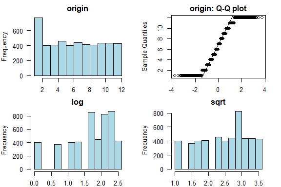

**[ day ]**

normality test : Shapiro-Wilk normality test

```
 statistic : 0.95745,  p-value : 6.45299E-36
```

skewness and kurtosis

| type | skewness | kurtosis |
| --- | --- | --- |
| original | 0.0042555 | 1.835291 |
| log transformation | -1.2966051 | 4.263629 |
| sqrt transformation | -0.5049487 | 2.294297 |

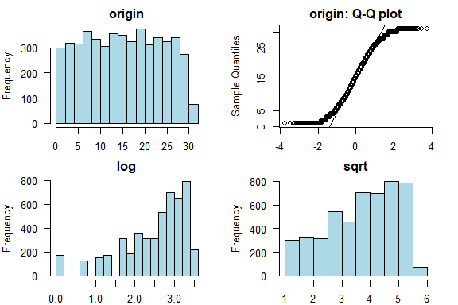

**[ dep_time ]**

normality test : Shapiro-Wilk normality test

```
 statistic : 0.96257,  p-value : 9.33405E-34
```

skewness and kurtosis

| type | skewness | kurtosis |
| --- | --- | --- |
| original | -0.0376955 | 1.918466 |
| log transformation | -3.6236193 | 39.392985 |
| sqrt transformation | -0.4751131 | 3.011788 |

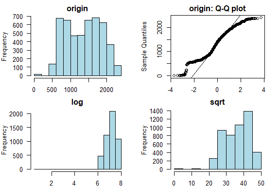

**[ sched_dep_time ]**

normality test : Shapiro-Wilk normality test

```
 statistic : 0.95053,  p-value : 4.18034E-38
```

skewness and kurtosis

| type | skewness | kurtosis |
| --- | --- | --- |
| original | 0.0000376 | 1.764789 |
| log transformation | -0.4237805 | 1.924316 |
| sqrt transformation | -0.2098710 | 1.785694 |

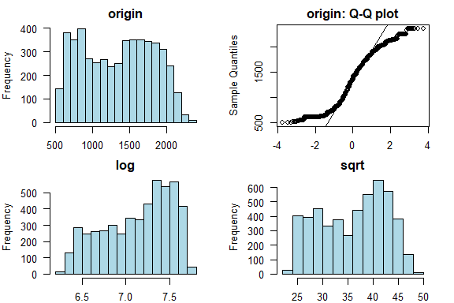

**[ dep_delay ]**

normality test : Shapiro-Wilk normality test

```
 statistic : 0.55509,  p-value : 4.08211E-77
```

skewness and kurtosis

| type | skewness | kurtosis |
| --- | --- | --- |
| original | 3.7036735 | 20.345446 |
| log transformation | NaN | NaN |
| sqrt transformation | 0.9675536 | 3.717422 |

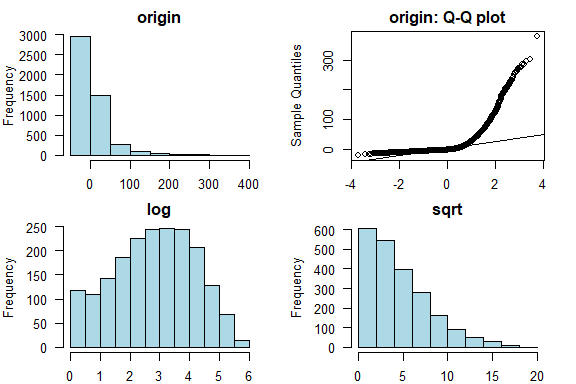

**[ arr_time ]**

normality test : Shapiro-Wilk normality test

```
 statistic : 0.95934,  p-value : 7.89188E-35
```

skewness and kurtosis

| type | skewness | kurtosis |
| --- | --- | --- |
| original | -0.4637441 | 2.779919 |
| log transformation | -4.6971416 | 31.338739 |
| sqrt transformation | -1.5862258 | 7.107610 |

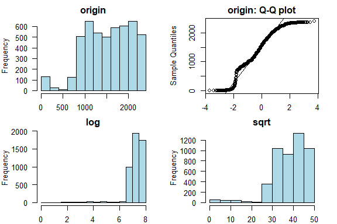

**[ sched_arr_time ]**

normality test : Shapiro-Wilk normality test

```
 statistic : 0.96419,  p-value : 1.68799E-33
```

skewness and kurtosis

| type | skewness | kurtosis |
| --- | --- | --- |
| original | -0.3100987 | 2.549092 |
| log transformation | -5.4608353 | 47.246731 |
| sqrt transformation | -1.3330627 | 7.104154 |

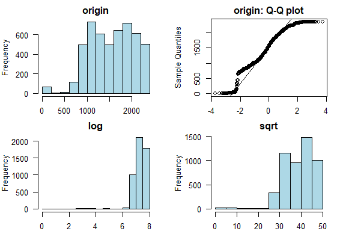

**[ flight ]**

normality test : Shapiro-Wilk normality test

```
 statistic : 0.89893,  p-value : 2.17042E-49
```

skewness and kurtosis

| type | skewness | kurtosis |
| --- | --- | --- |
| original | 0.6295501 | 2.098689 |
| log transformation | -1.3824793 | 5.522180 |
| sqrt transformation | 0.0534683 | 1.888155 |

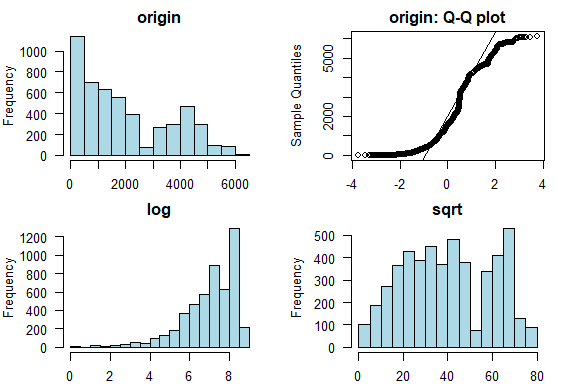

**[ air_time ]**

normality test : Shapiro-Wilk normality test

```
 statistic : 0.89064,  p-value : 3.44962E-50
```

skewness and kurtosis

| type | skewness | kurtosis |
| --- | --- | --- |
| original | 1.1071984 | 4.105084 |
| log transformation | -0.1666572 | 2.353317 |
| sqrt transformation | 0.4739507 | 2.614729 |

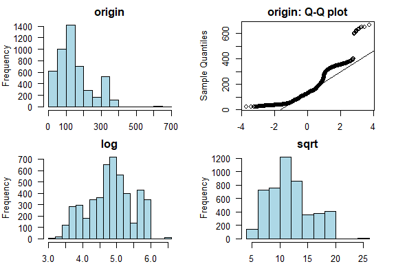

**[ distance ]**

normality test : Shapiro-Wilk normality test

```
 statistic : 0.87698,  p-value : 9.24828E-53
```

skewness and kurtosis

| type | skewness | kurtosis |
| --- | --- | --- |
| original | 1.1026081 | 4.096058 |
| log transformation | -0.3874769 | 2.525272 |
| sqrt transformation | 0.3854207 | 2.544728 |

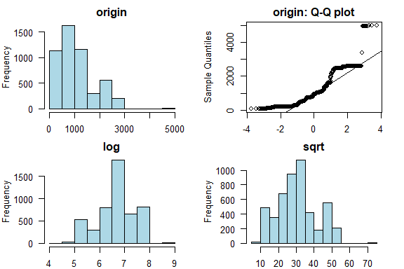

**[ hour ]**

normality test : Shapiro-Wilk normality test

```
 statistic : 0.95313,  p-value : 2.59751E-37
```

skewness and kurtosis

| type | skewness | kurtosis |
| --- | --- | --- |
| original | -0.0298202 | 1.831007 |
| log transformation | -0.4974220 | 2.073631 |
| sqrt transformation | -0.2602830 | 1.884754 |

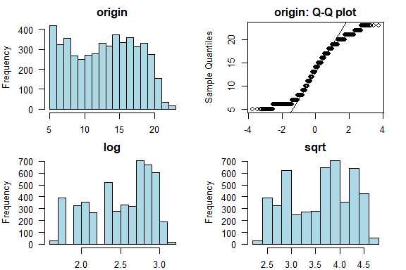

**[ minute ]**

normality test : Shapiro-Wilk normality test

```
 statistic : 0.92576,  p-value : 2.4966E-44
```

skewness and kurtosis

| type | skewness | kurtosis |
| --- | --- | --- |
| original | 0.1159441 | 1.780858 |
| log transformation | NaN | NaN |
| sqrt transformation | -0.6348613 | 2.159299 |

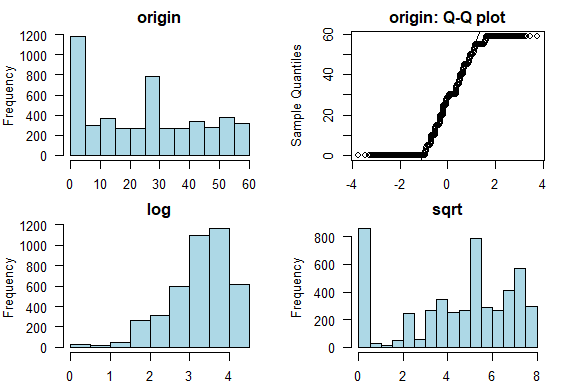

# 3 Relationship Between Variables

## 3.1 Correlation Coefficient

### 3.1.1 Correlation Coefficient by Variable Combination

Table of correlation coefficients (0.5 or more)

| Variable1 | Variable2 | Correlation Coefficient |
| --- | --- | --- |
| hour | sched_dep_time | 0.9991483 |
| distance | air_time | 0.9906496 |
| sched_dep_time | dep_time | 0.9546169 |
| hour | dep_time | 0.9533056 |
| arr_delay | dep_delay | 0.9148028 |
| sched_arr_time | arr_time | 0.7889971 |
| sched_arr_time | dep_time | 0.7846824 |
| sched_arr_time | sched_dep_time | 0.7833425 |
| hour | sched_arr_time | 0.7832825 |
| arr_time | dep_time | 0.6607789 |
| arr_time | sched_dep_time | 0.6426802 |
| hour | arr_time | 0.6426514 |

### 3.1.2 Correlation Plot of Numerical Variables

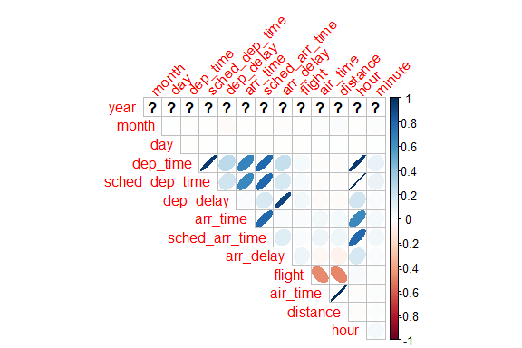

# 4 Target based Analysis

## 4.1 Grouped Descriptive Statistics

### 4.1.1 Grouped Numerical Variables

**[ month ]**

Simple Linear Model Information

```
 Residual standard error: 45 on 327344 degrees of freedom
 Multiple R-squared:  3e-04,    Adjusted R-squared:  3e-04
 F-statistic: 99 on 1 and 327344 DF,  p-value: 2.63337468622021e-23
```

Coefficients:

Simple Linear Model coefficients : month

|  | Estimate | Std. Error | t value | Pr(>\|t\|) |
| --- | --- | --- | --- | --- |
| (Intercept) | 8.39 | 0.17 | 49.61 | 0 |
| month | -0.23 | 0.02 | -9.95 | 0 |

Visualization:

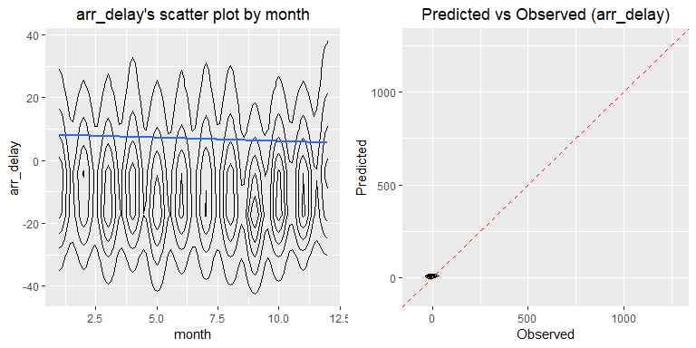

**[ day ]**

Simple Linear Model Information

```
 Residual standard error: 45 on 327344 degrees of freedom
 Multiple R-squared:  0,    Adjusted R-squared:  0
 F-statistic: 0 on 1 and 327344 DF,  p-value: 0.85511010203674
```

Coefficients:

Simple Linear Model coefficients : day

|  | Estimate | Std. Error | t value | Pr(>\|t\|) |
| --- | --- | --- | --- | --- |
| (Intercept) | 6.92 | 0.16 | 43.21 | 0.00 |
| day | 0.00 | 0.01 | -0.18 | 0.86 |

Visualization:

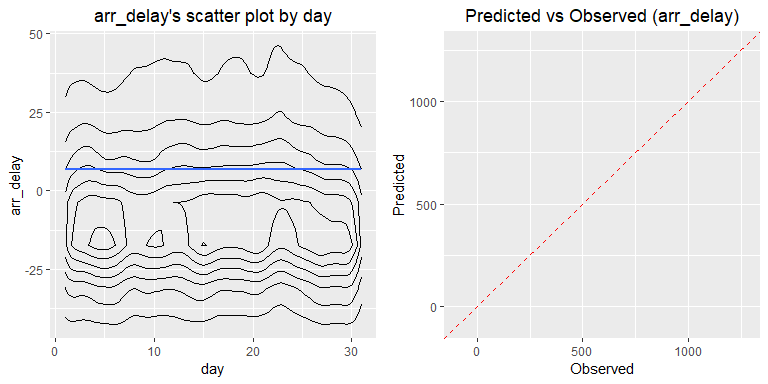

**[ dep_time ]**

Simple Linear Model Information

```
 Residual standard error: 43 on 327344 degrees of freedom
 Multiple R-squared:  0.05397,  Adjusted R-squared:  0.05396
 F-statistic: 18673 on 1 and 327344 DF,  p-value: 0
```

Coefficients:

Simple Linear Model coefficients : dep\_time

|  | Estimate | Std. Error | t value | Pr(>\|t\|) |
| --- | --- | --- | --- | --- |
| (Intercept) | -21.74 | 0.22 | -97.55 | 0 |
| dep_time | 0.02 | 0.00 | 136.65 | 0 |

Visualization:

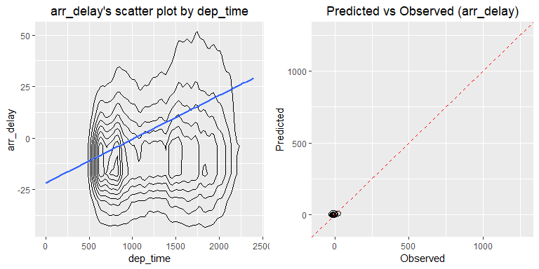

**[ sched_dep_time ]**

Simple Linear Model Information

```
 Residual standard error: 44 on 327344 degrees of freedom
 Multiple R-squared:  0.03024,  Adjusted R-squared:  0.03024
 F-statistic: 10208 on 1 and 327344 DF,  p-value: 0
```

Coefficients:

Simple Linear Model coefficients : sched\_dep\_time

|  | Estimate | Std. Error | t value | Pr(>\|t\|) |
| --- | --- | --- | --- | --- |
| (Intercept) | -15.36 | 0.23 | -65.84 | 0 |
| sched_dep_time | 0.02 | 0.00 | 101.03 | 0 |

Visualization:

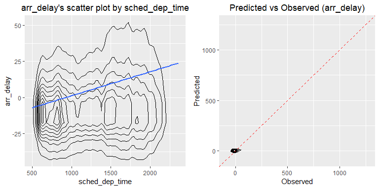

**[ dep_delay ]**

Simple Linear Model Information

```
 Residual standard error: 18 on 327344 degrees of freedom
 Multiple R-squared:  0.83686,  Adjusted R-squared:  0.83686
 F-statistic: 1679228 on 1 and 327344 DF,  p-value: 0
```

Coefficients:

Simple Linear Model coefficients : dep\_delay

|  | Estimate | Std. Error | t value | Pr(>\|t\|) |
| --- | --- | --- | --- | --- |
| (Intercept) | -5.90 | 0.03 | -178.67 | 0 |
| dep_delay | 1.02 | 0.00 | 1295.85 | 0 |

Visualization:

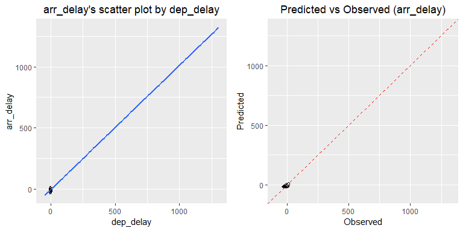

**[ arr_time ]**

Simple Linear Model Information

```
 Residual standard error: 45 on 327344 degrees of freedom
 Multiple R-squared:  6e-04,    Adjusted R-squared:  6e-04
 F-statistic: 196 on 1 and 327344 DF,  p-value: 1.36749017014078e-44
```

Coefficients:

Simple Linear Model coefficients : arr\_time

|  | Estimate | Std. Error | t value | Pr(>\|t\|) |
| --- | --- | --- | --- | --- |
| (Intercept) | 3.82 | 0.23 | 16.36 | 0 |
| arr_time | 0.00 | 0.00 | 14.01 | 0 |

Visualization:

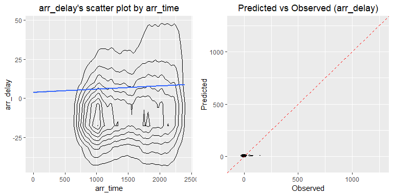

**[ sched_arr_time ]**

Simple Linear Model Information

```
 Residual standard error: 44 on 327344 degrees of freedom
 Multiple R-squared:  0.01776,  Adjusted R-squared:  0.01776
 F-statistic: 5918 on 1 and 327344 DF,  p-value: 0
```

Coefficients:

Simple Linear Model coefficients : sched\_arr\_time

|  | Estimate | Std. Error | t value | Pr(>\|t\|) |
| --- | --- | --- | --- | --- |
| (Intercept) | -11.41 | 0.25 | -45.61 | 0 |
| sched_arr_time | 0.01 | 0.00 | 76.93 | 0 |

Visualization:

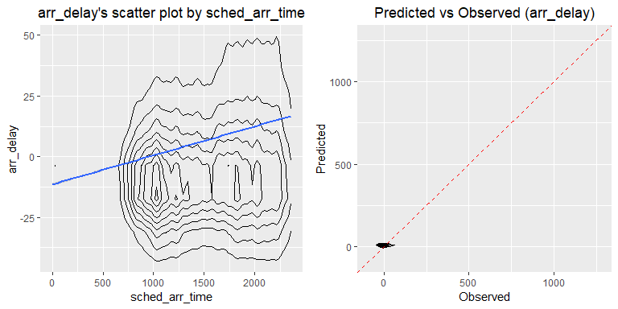

**[ flight ]**

Simple Linear Model Information

```
 Residual standard error: 45 on 327344 degrees of freedom
 Multiple R-squared:  0.00531,  Adjusted R-squared:  0.00531
 F-statistic: 1747 on 1 and 327344 DF,  p-value: 0
```

Coefficients:

Simple Linear Model coefficients : flight

|  | Estimate | Std. Error | t value | Pr(>\|t\|) |
| --- | --- | --- | --- | --- |
| (Intercept) | 3 | 0.12 | 24.69 | 0 |
| flight | 0 | 0.00 | 41.80 | 0 |

Visualization:

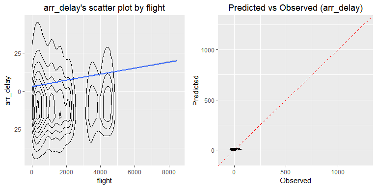

**[ air_time ]**

Simple Linear Model Information

```
 Residual standard error: 45 on 327344 degrees of freedom
 Multiple R-squared:  0.00125,  Adjusted R-squared:  0.00124
 F-statistic: 408 on 1 and 327344 DF,  p-value: 9.56458234735319e-91
```

Coefficients:

Simple Linear Model coefficients : air\_time

|  | Estimate | Std. Error | t value | Pr(>\|t\|) |
| --- | --- | --- | --- | --- |
| (Intercept) | 9.43 | 0.15 | 63.86 | 0 |
| air_time | -0.02 | 0.00 | -20.21 | 0 |

Visualization:

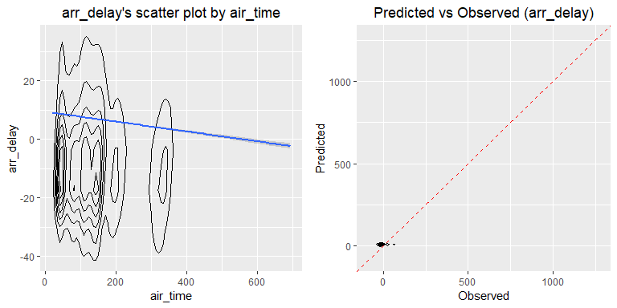

**[ distance ]**

Simple Linear Model Information

```
 Residual standard error: 45 on 327344 degrees of freedom
 Multiple R-squared:  0.00383,  Adjusted R-squared:  0.00382
 F-statistic: 1258 on 1 and 327344 DF,  p-value: 5.70629795066226e-275
```

Coefficients:

Simple Linear Model coefficients : distance

|  | Estimate | Std. Error | t value | Pr(>\|t\|) |
| --- | --- | --- | --- | --- |
| (Intercept) | 10.83 | 0.14 | 79.91 | 0 |
| distance | 0.00 | 0.00 | -35.46 | 0 |

Visualization:

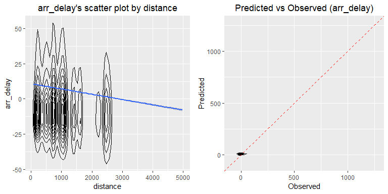

**[ hour ]**

Simple Linear Model Information

```
 Residual standard error: 44 on 327344 degrees of freedom
 Multiple R-squared:  0.03009,  Adjusted R-squared:  0.03008
 F-statistic: 10154 on 1 and 327344 DF,  p-value: 0
```

Coefficients:

Simple Linear Model coefficients : hour

|  | Estimate | Std. Error | t value | Pr(>\|t\|) |
| --- | --- | --- | --- | --- |
| (Intercept) | -14.93 | 0.23 | -64.96 | 0 |
| hour | 1.66 | 0.02 | 100.77 | 0 |

Visualization:

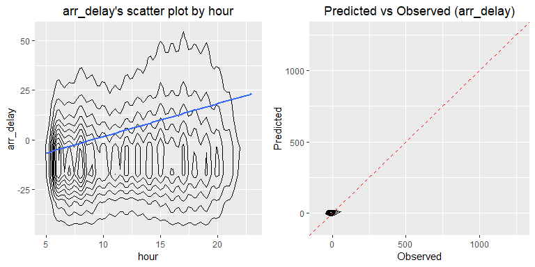

**[ minute ]**

Simple Linear Model Information

```
 Residual standard error: 45 on 327344 degrees of freedom
 Multiple R-squared:  0.00046,  Adjusted R-squared:  0.00046
 F-statistic: 152 on 1 and 327344 DF,  p-value: 7.50911982479997e-35
```

Coefficients:

Simple Linear Model coefficients : minute

|  | Estimate | Std. Error | t value | Pr(>\|t\|) |
| --- | --- | --- | --- | --- |
| (Intercept) | 5.59 | 0.13 | 42.46 | 0 |
| minute | 0.05 | 0.00 | 12.32 | 0 |

Visualization:

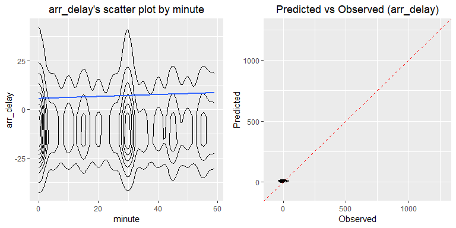

## 4.2 Grouped Relationship Between Variables

### 4.2.1 Grouped Correlation Coefficient

```
Numerical target variables are not supported.
```

### 4.2.2 Grouped Correlation Plot of Numerical Variables

```
Numerical target variables are not supported.
```